# Perfect Garden Graph

Seth Buesing

```r
library(tidyverse)         # for graphing and data cleaning
library(ggthemes)
library(lubridate)         # for working with dates
library(colorRamps)
library(remotes)
# For the garden data, you need to first install the remotes library, if you haven't already
# Then, install the gardenR library, if you haven't already. Do this by uncommenting the code below (delete the hashtag) and running it. Then, you should delete this line of code or add the hashtag back so you don't reinstall each time.
# `remotes::install_github("llendway/gardenR")
# Once the library is installed, you don't need to install it again, but each time you need to load the library using the code below. You will know if you haven't installed the library if the code below produces an error.
library(gardenR)
theme_set(theme_minimal())  # set a theme if desired
```

```r
# load the garden data
data(garden_harvest)
```

Explain the question you hope to answer and create the graph below in the Graph Week 1 section. For the first week, you may not have the skills quite yet to create exactly what you want to create - that’s ok! Get as close as you can, and the instructors will give you feedback to help you out. You can summarize the data in any way you’d like. Add R code chunks and comment code as needed. As the weeks go by, you will continue to build on this file by putting new code in the next Graph sections. You will keep all the old code, add your instructor’s feedback by copying and pasting it from moodle (found in the Grade section of moodle), and make improvements from my suggestions and from other ideas you have. Having the old code and graphs and the instructor feedback will help you (and the instructors) easily see the progress throughout the course.

FYI, Prof. Lisa just added 2021 data to the `gardenR` package. If you want to use that data (either with the 2020 data or by itself), you will need to reinstall the package. Just a warning that variable names were maintained but names of vegetables and varieties changed in a few cases over the two years (oops). After you load the dataset, you can search for gardenR in the Help tab to find out more about the new datasets.

## Graph Week 1

Question I hope to answer: (write your description here - 1-2 sentences should be plenty)

I’m going to try to see what the greatest yield crop is over time- which time of summer is the “bean” season vs. “pea season”. My approach is going to be finding the maximum vegetable harvested each day, and displaying the weight harvested as well.

```r
garden_harvest_maxbyday <- garden_harvest %>%
    group_by(date, vegetable) %>%
      summarize(veg_total = sum(weight))  %>%
          mutate(weight_kg = veg_total/1000) %>%
            slice_max(weight_kg, n= 1)
```

The data should now be grouped by the maximum vegetable harvested each day, and the weight harvested.

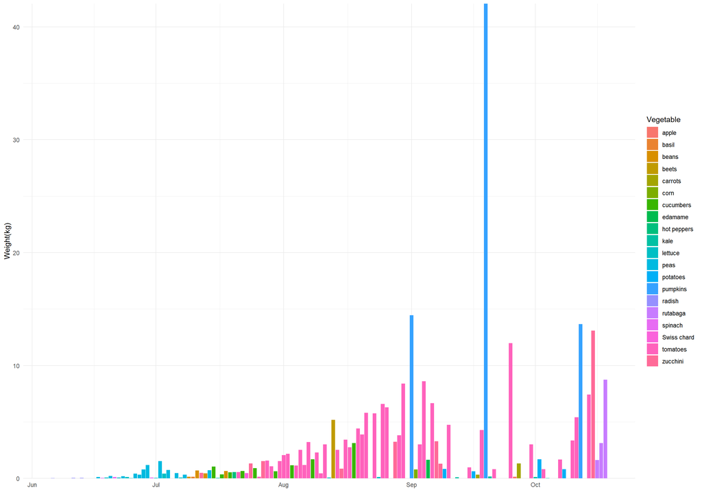

```r
    garden_harvest_maxbyday %>%
        ggplot(aes(x = date, y = weight_kg)) +
        geom_col(aes(fill = vegetable), position = "dodge") +
        scale_y_continuous(expand = c(0, 0)) +
        scale_fill_hue() +
        labs(x= "",
             y = "Weight(kg)" ,
             fill = "Vegetable")
```

Instructor’s feedback: (copy the feedback from moodle here)

I love this idea - very creative! Because there are so many vegetables, the color legend is tricky to read. I think there might be a couple reasons. So, first, after summarizing your data, use fct_drop() to get rid of any unused vegetable levels. Then, create a 2nd graph that is a barplot with vegetable on the y-axis and the number of times they were the maximum on the x-axis. Eventually you’ll add that inside this plot, but for now, it can be separate. Fill the bars by vegetable name but remove the legend and remove it in the orginal graph, too. This new plot will take the place of the original legend, while providing even more information. Add a title that communicates what’s in the plot - you may also need a subtitle since it’s a bit complex.

## Graph Week 2

Question I hope to answer: (probably the same as previous week but may change slightly) I’m still going to try to look at the what the greatest yield crop is each day, but I’m going to add some clarifications as you suggested. I’m also starting to think about what I could do to expand this question, because I feel like it’s a little too simple to work on for the rest of the semester.

So here I had to modify my data set a little bit so that I could order the color assignment by frequency of appearance, which involved adding a mutated count of the number of appearances for any vegetable. Ther ewere issues in getting this data set to work with the next bar graph so I take a similar approach but instead through summarizing.

```r
garden_harvest_maxbyday <- garden_harvest %>%
  group_by(date, vegetable) %>%
  summarize(veg_total = sum(weight))  %>%
  mutate(weight_kg = veg_total/1000) %>%
  slice_max(weight_kg, n= 1) %>%
  ungroup() %>%
  group_by(vegetable) %>%
  mutate(n = n()) %>%
  arrange(desc(n))
garden_harvest_maxbyday
```

| date | vegetable | veg_total | weight_kg | n |
| --- | --- | --- | --- | --- |
| 2020-07-21 | tomatoes | 562 | 0.562 | 39 |
| 2020-07-26 | tomatoes | 148 | 0.148 | 39 |
| 2020-07-28 | tomatoes | 1572 | 1.572 | 39 |
| 2020-07-29 | tomatoes | 1084 | 1.084 | 39 |
| 2020-07-31 | tomatoes | 1527 | 1.527 | 39 |
| 2020-08-01 | tomatoes | 2075 | 2.075 | 39 |
| 2020-08-02 | tomatoes | 2171 | 2.171 | 39 |
| 2020-08-04 | tomatoes | 1148 | 1.148 | 39 |
| 2020-08-05 | tomatoes | 2523 | 2.523 | 39 |
| 2020-08-06 | tomatoes | 1178 | 1.178 | 39 |

[output cut: 104 more lines]

Also, I added labels, which could use a little bit of cleaning up but still add to the comprehensibility of the graph.

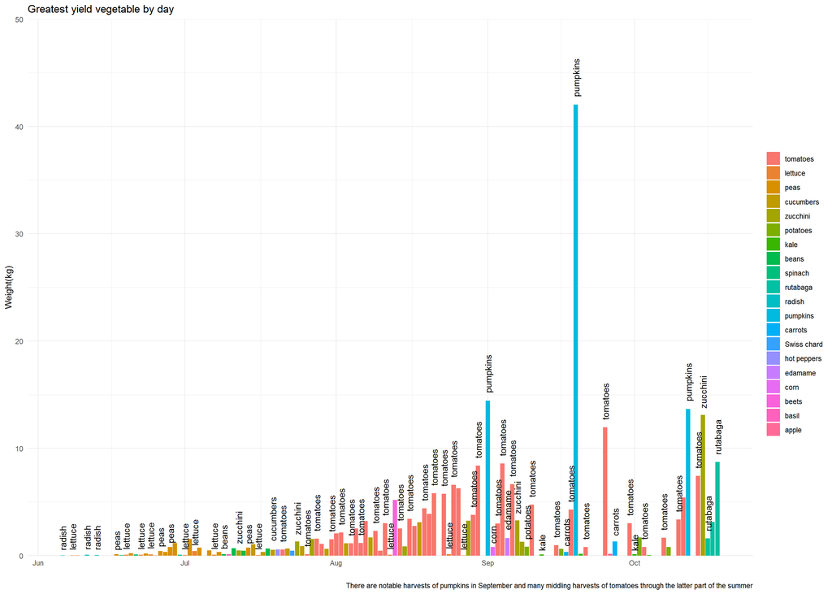

```r
  garden_harvest_maxbyday %>%
        ggplot(aes(y = weight_kg, x = date)) +
        geom_col(aes(fill = fct_rev(fct_reorder(vegetable, n))), position = "dodge") +
        scale_y_continuous(limits = c(0,50),expand = c(0, 0)) +
        scale_fill_hue() +
        geom_text(aes(label = vegetable), angle = 90, check_overlap = TRUE, hjust = -.2) +
        labs(x= "",
             y = "Weight(kg)" ,
             fill = "",
             title = "Greatest yield vegetable by day",
             caption = "There are notable harvests of pumpkins in September and many middling harvests of tomatoes through the latter part of the summer")
```

Here’s the additional graph I made, to show the frequency of appearance for each vegetable.

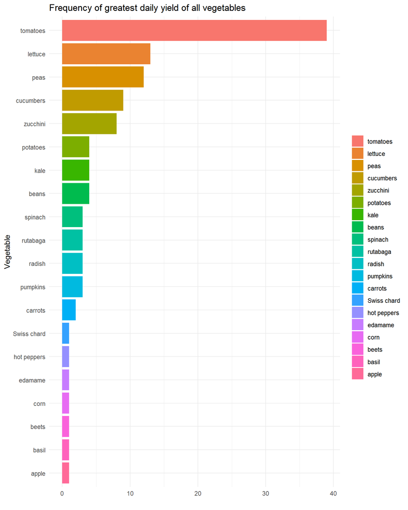

```r
garden_harvest %>%
  group_by(date, vegetable) %>%
  summarize(veg_total = sum(weight))  %>%
  mutate(weight_kg = veg_total/1000) %>%
  slice_max(weight_kg, n= 1) %>%
  ungroup() %>%
  group_by(vegetable) %>%
  summarize(n = n()) %>%
    ggplot(aes(y = fct_reorder(vegetable, n), x = n)) +
      geom_col(aes(fill = fct_rev(fct_reorder(vegetable, n)))) +
      scale_fill_hue() +
      labs(x = "",
           y = "Vegetable",
           fill = "",
           title = "Frequency of greatest daily yield of all vegetables")
```